# Part I - Ford GoBike System Data

## Introduction

> This data set includes information about individual rides made in a Ford GoBike covering the greater San Francisco Bay area.

> Ford GoBike is a regional public bicycle sharing system in the San Francisco Bay Area, California. Beginning operation in August 2013 as Bay Area Bike Share, the Ford GoBike system currently has over 2,600 bicycles in 262 stations across San Francisco, East Bay and San Jose. On June 28, 2017, the system officially launched as Ford GoBike in a partnership with Ford Motor Company.

## Preliminary Wrangling

```python
# import all packages and set plots to be embedded inline
import numpy as np
import pandas as pd
import matplotlib.pyplot as plt
import seaborn as sns

%matplotlib inline
```

> Load in your dataset and describe its properties through the questions below. Try and motivate your exploration goals through this section.

```python
raw_df = pd.read_csv('201902-fordgobike-tripdata.csv')
raw_df.head()
```

|  | duration_sec | start_time | end_time | start_station_id | start_station_name | start_station_latitude | start_station_longitude | end_station_id | end_station_name | end_station_latitude | end_station_longitude | bike_id | user_type | member_birth_year | member_gender | bike_share_for_all_trip |
| --- | --- | --- | --- | --- | --- | --- | --- | --- | --- | --- | --- | --- | --- | --- | --- | --- |
| 0 | 52185 | 2019-02-28 17:32:10.1450 | 2019-03-01 08:01:55.9750 | 21.0 | Montgomery St BART Station (Market St at 2nd St) | 37.789625 | -122.400811 | 13.0 | Commercial St at Montgomery St | 37.794231 | -122.402923 | 4902 | Customer | 1984.0 | Male | No |
| 1 | 42521 | 2019-02-28 18:53:21.7890 | 2019-03-01 06:42:03.0560 | 23.0 | The Embarcadero at Steuart St | 37.791464 | -122.391034 | 81.0 | Berry St at 4th St | 37.775880 | -122.393170 | 2535 | Customer | NaN | NaN | No |
| 2 | 61854 | 2019-02-28 12:13:13.2180 | 2019-03-01 05:24:08.1460 | 86.0 | Market St at Dolores St | 37.769305 | -122.426826 | 3.0 | Powell St BART Station (Market St at 4th St) | 37.786375 | -122.404904 | 5905 | Customer | 1972.0 | Male | No |
| 3 | 36490 | 2019-02-28 17:54:26.0100 | 2019-03-01 04:02:36.8420 | 375.0 | Grove St at Masonic Ave | 37.774836 | -122.446546 | 70.0 | Central Ave at Fell St | 37.773311 | -122.444293 | 6638 | Subscriber | 1989.0 | Other | No |
| 4 | 1585 | 2019-02-28 23:54:18.5490 | 2019-03-01 00:20:44.0740 | 7.0 | Frank H Ogawa Plaza | 37.804562 | -122.271738 | 222.0 | 10th Ave at E 15th St | 37.792714 | -122.248780 | 4898 | Subscriber | 1974.0 | Male | Yes |

### Dataset structure

```python
print("Number of rows: ", raw_df.shape[0])
print("Number of columns: ", raw_df.shape[1])
print("Columns:", ", ".join(raw_df.columns))
```

```
Number of rows:  183412
Number of columns:  16
Columns: duration_sec, start_time, end_time, start_station_id, start_station_name, start_station_latitude, start_station_longitude, end_station_id, end_station_name, end_station_latitude, end_station_longitude, bike_id, user_type, member_birth_year, member_gender, bike_share_for_all_trip
```

```python
# Statistical summary of the dataset
raw_df.describe()
```

|  | duration_sec | start_station_id | start_station_latitude | start_station_longitude | end_station_id | end_station_latitude | end_station_longitude | bike_id | member_birth_year |
| --- | --- | --- | --- | --- | --- | --- | --- | --- | --- |
| count | 183412.000000 | 183215.000000 | 183412.000000 | 183412.000000 | 183215.000000 | 183412.000000 | 183412.000000 | 183412.000000 | 175147.000000 |
| mean | 726.078435 | 138.590427 | 37.771223 | -122.352664 | 136.249123 | 37.771427 | -122.352250 | 4472.906375 | 1984.806437 |
| std | 1794.389780 | 111.778864 | 0.099581 | 0.117097 | 111.515131 | 0.099490 | 0.116673 | 1664.383394 | 10.116689 |
| min | 61.000000 | 3.000000 | 37.317298 | -122.453704 | 3.000000 | 37.317298 | -122.453704 | 11.000000 | 1878.000000 |
| 25% | 325.000000 | 47.000000 | 37.770083 | -122.412408 | 44.000000 | 37.770407 | -122.411726 | 3777.000000 | 1980.000000 |
| 50% | 514.000000 | 104.000000 | 37.780760 | -122.398285 | 100.000000 | 37.781010 | -122.398279 | 4958.000000 | 1987.000000 |
| 75% | 796.000000 | 239.000000 | 37.797280 | -122.286533 | 235.000000 | 37.797320 | -122.288045 | 5502.000000 | 1992.000000 |
| max | 85444.000000 | 398.000000 | 37.880222 | -121.874119 | 398.000000 | 37.880222 | -121.874119 | 6645.000000 | 2001.000000 |

```python
# As we can see that the start_time, end_time are in object format, we need to convert them to datetime format
raw_df['start_time'] = pd.to_datetime(raw_df['start_time'])
raw_df['end_time'] = pd.to_datetime(raw_df['end_time'])
```

```python
# Check dtype of columns after conversion
raw_df.info()
```

```
<class 'pandas.core.frame.DataFrame'>
RangeIndex: 183412 entries, 0 to 183411
Data columns (total 16 columns):
 #   Column                   Non-Null Count   Dtype
---  ------                   --------------   -----
 0   duration_sec             183412 non-null  int64
 1   start_time               183412 non-null  datetime64[ns]
 2   end_time                 183412 non-null  datetime64[ns]
 3   start_station_id         183215 non-null  float64
 4   start_station_name       183215 non-null  object
 5   start_station_latitude   183412 non-null  float64
 6   start_station_longitude  183412 non-null  float64
 7   end_station_id           183215 non-null  float64
 8   end_station_name         183215 non-null  object
 9   end_station_latitude     183412 non-null  float64
 10  end_station_longitude    183412 non-null  float64
 11  bike_id                  183412 non-null  int64
 12  user_type                183412 non-null  object
 13  member_birth_year        175147 non-null  float64
 14  member_gender            175147 non-null  object
 15  bike_share_for_all_trip  183412 non-null  object
dtypes: datetime64[ns](2), float64(7), int64(2), object(5)
memory usage: 22.4+ MB
```

```python
# Check for missing values in the dataset
raw_df.isnull().sum()
```

```
duration_sec                  0
start_time                    0
end_time                      0
start_station_id            197
start_station_name          197
start_station_latitude        0
start_station_longitude       0
end_station_id              197
end_station_name            197
end_station_latitude          0
end_station_longitude         0
bike_id                       0
user_type                     0
member_birth_year          8265
member_gender              8265
bike_share_for_all_trip       0
dtype: int64
```

--> Need to remove them to ensure the completeness of the dataset

```python
# Check for duplicates in the dataset
raw_df.duplicated().sum()
```

```
0
```

```python
# Filter out the rows that missing any value and duplicates
df = raw_df.dropna().drop_duplicates()
```

```python
# Take a glimpse at the dataset after cleaning
df.head()
```

|  | duration_sec | start_time | end_time | start_station_id | start_station_name | start_station_latitude | start_station_longitude | end_station_id | end_station_name | end_station_latitude | end_station_longitude | bike_id | user_type | member_birth_year | member_gender | bike_share_for_all_trip |
| --- | --- | --- | --- | --- | --- | --- | --- | --- | --- | --- | --- | --- | --- | --- | --- | --- |
| 0 | 52185 | 2019-02-28 17:32:10.145 | 2019-03-01 08:01:55.975 | 21.0 | Montgomery St BART Station (Market St at 2nd St) | 37.789625 | -122.400811 | 13.0 | Commercial St at Montgomery St | 37.794231 | -122.402923 | 4902 | Customer | 1984.0 | Male | No |
| 2 | 61854 | 2019-02-28 12:13:13.218 | 2019-03-01 05:24:08.146 | 86.0 | Market St at Dolores St | 37.769305 | -122.426826 | 3.0 | Powell St BART Station (Market St at 4th St) | 37.786375 | -122.404904 | 5905 | Customer | 1972.0 | Male | No |
| 3 | 36490 | 2019-02-28 17:54:26.010 | 2019-03-01 04:02:36.842 | 375.0 | Grove St at Masonic Ave | 37.774836 | -122.446546 | 70.0 | Central Ave at Fell St | 37.773311 | -122.444293 | 6638 | Subscriber | 1989.0 | Other | No |
| 4 | 1585 | 2019-02-28 23:54:18.549 | 2019-03-01 00:20:44.074 | 7.0 | Frank H Ogawa Plaza | 37.804562 | -122.271738 | 222.0 | 10th Ave at E 15th St | 37.792714 | -122.248780 | 4898 | Subscriber | 1974.0 | Male | Yes |
| 5 | 1793 | 2019-02-28 23:49:58.632 | 2019-03-01 00:19:51.760 | 93.0 | 4th St at Mission Bay Blvd S | 37.770407 | -122.391198 | 323.0 | Broadway at Kearny | 37.798014 | -122.405950 | 5200 | Subscriber | 1959.0 | Male | No |

```python
print("After cleaning the dataset:")
print("Number of rows: ", df.shape[0])
print("Number of columns: ", df.shape[1])
```

```
After cleaning the dataset:
Number of rows:  174952
Number of columns:  16
```

```python
df["user_type"].value_counts()
```

```
user_type
Subscriber    158386
Customer       16566
Name: count, dtype: int64
```

```python
df["member_gender"].value_counts()
```

```
member_gender
Male      130500
Female     40805
Other       3647
Name: count, dtype: int64
```

### What is the structure of your dataset?

> The raw dataset contains 183412 raw records of trips for FordGoBike. Each record has 16 features, which are:
> - duration_sec: The duration of the bike trip in second
> - start_time, end_time: Start and end time of the trip
> - start_station_id, start_station_name, start_station_latitude, start_station_longitude, end_station_id, end_station_name, end_station_latitude, end_station_longitude: Information about the start station and end station of the trip
> - bike_id: ID of the rented bike
> - user_type: User type - Subcriber or Customer
> - member_birth_year: birth year of the user
> - member_gender: gender of the yser
> - bike_share_for_all_trip: boolean indicates whether a bike share trip was part of the program

> Most of them are numerical variables, beside datetime for start_time, end_time and object for station_name, user_type, gender and bike_share_for_all_trip After cleaning some quality issues like missing value and duplicates, the dataset contains 174952 records left.

### What is/are the main feature(s) of interest in your dataset?

> The feature that I interested in the most is the trip duration, and the relationship between it and other factors

### What features in the dataset do you think will help support your investigation into your feature(s) of interest?

> In my own prediction, I would first go for the start_time, user_type, member_gender and member_birth_year

## Univariate Exploration

> In this section, investigate distributions of individual variables. If you see unusual points or outliers, take a deeper look to clean things up and prepare yourself to look at relationships between variables.

> **Rubric Tip**: The project (Parts I alone) should have at least 15 visualizations distributed over univariate, bivariate, and multivariate plots to explore many relationships in the data set. Use reasoning to justify the flow of the exploration.

> **Rubric Tip**: Use the "Question-Visualization-Observations" framework throughout the exploration. This framework involves **asking a question from the data, creating a visualization to find answers, and then recording observations after each visualisation.**

First, investigate the of interest feature: duration_sec. I will plot a historgram chart with binsize of 5 mins ~ 300 seconds

### duraction_sec

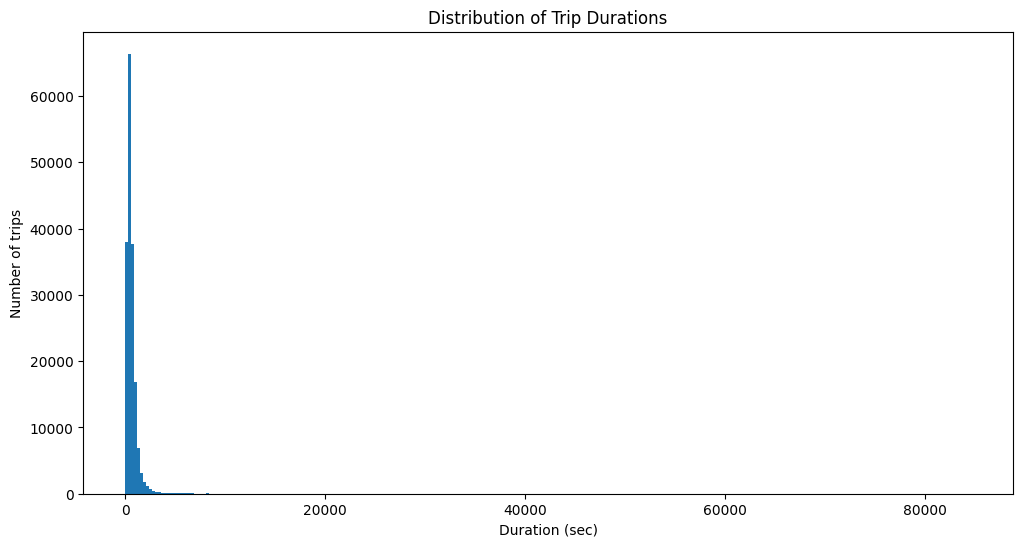

```python
bin_size = 300
bins = np.arange(0, df['duration_sec'].max() + bin_size, bin_size)
plt.figure(figsize=(12, 6))
plt.hist(data=df, x='duration_sec', bins=bins)
plt.xlabel('Duration (sec)')
plt.ylabel('Number of trips')
plt.title('Distribution of Trip Durations')
plt.show()
```

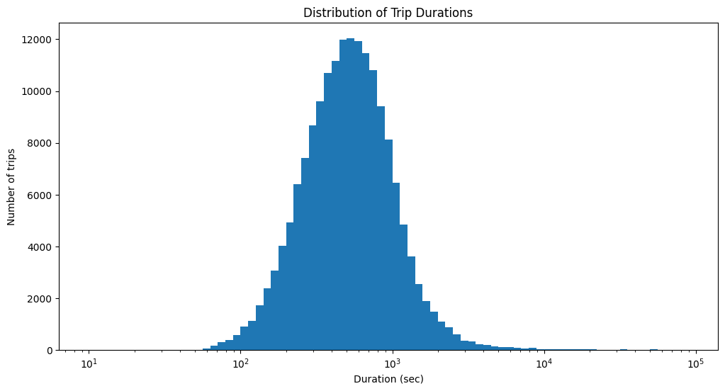

```python
log_bin_size = 0.05
log_bins = 10 ** np.arange(np.floor(np.log10(df["duration_sec"]).min()), np.log10(df["duration_sec"]).max() + log_bin_size, log_bin_size)
plt.figure(figsize=(12, 6))
plt.hist(data=df, x='duration_sec', bins=log_bins)
plt.xscale('log')
plt.xlabel('Duration (sec)')
plt.ylabel('Number of trips')
plt.title('Distribution of Trip Durations')
plt.show()
```

The distribution looks alike the normal distribution, let's investigate its IQR

```python
df["duration_sec"].describe()
```

```
count    174952.000000
mean        704.002744
std        1642.204905
min          61.000000
25%         323.000000
50%         510.000000
75%         789.000000
max       84548.000000
Name: duration_sec, dtype: float64
```

```python
duration_iqr = df["duration_sec"].quantile(0.75) - df["duration_sec"].quantile(0.25)
duration_upper_whisker_bound = min(df["duration_sec"].max(), df["duration_sec"].quantile(0.75) + 1.5 * duration_iqr)
duration_lower_whisker_bound = max(df["duration_sec"].min(), df["duration_sec"].quantile(0.25) - 1.5 * duration_iqr)
print("IQR: ", duration_iqr)
print("Upper whisker bound: ", duration_upper_whisker_bound)
print("Lower whisker bound: ", duration_lower_whisker_bound)
```

```
IQR:  466.0
Upper whisker bound:  1488.0
Lower whisker bound:  61
```

Let's investigate the age of users, regarding the member_birth_year feature

### member_birth_year - member_age

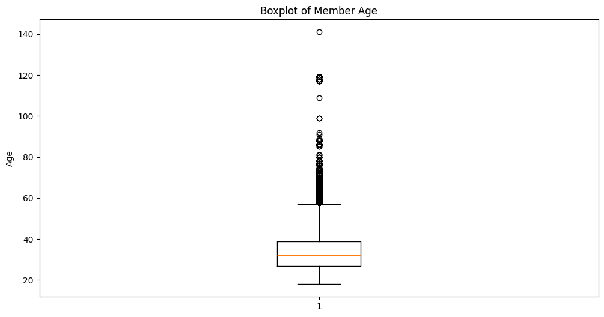

```python
df["member_age"] = 2019 - df["member_birth_year"]
plt.figure(figsize=(12, 6))
plt.boxplot(df["member_age"])
plt.ylabel("Age")
plt.title("Boxplot of Member Age")
plt.show()
```

```python
df["member_age"].describe()
```

```
count    174952.000000
mean         34.196865
std          10.118731
min          18.000000
25%          27.000000
50%          32.000000
75%          39.000000
max         141.000000
Name: member_age, dtype: float64
```

As we can see, this member_age feature is not well distributed as it contains many outliers (above 100 years old,...). So, I will remove these outlier to make the data more accurate

```python
age_iqr = df["member_age"].quantile(0.75) - df["member_age"].quantile(0.25)
age_upper_whisker_bound = min(df["member_age"].max(), df["member_age"].quantile(0.75) + 1.5 * age_iqr)
print("Age upper whisker bound: ", age_upper_whisker_bound)
print("Remove outlier records with member age above 73")
df = df[df["member_age"] <= 73]
df.head()
```

```
Age upper whisker bound:  57.0
Remove outlier records with member age above 73
```

|  | duration_sec | start_time | end_time | start_station_id | start_station_name | start_station_latitude | start_station_longitude | end_station_id | end_station_name | end_station_latitude | end_station_longitude | bike_id | user_type | member_birth_year | member_gender | bike_share_for_all_trip | member_age |
| --- | --- | --- | --- | --- | --- | --- | --- | --- | --- | --- | --- | --- | --- | --- | --- | --- | --- |
| 0 | 52185 | 2019-02-28 17:32:10.145 | 2019-03-01 08:01:55.975 | 21.0 | Montgomery St BART Station (Market St at 2nd St) | 37.789625 | -122.400811 | 13.0 | Commercial St at Montgomery St | 37.794231 | -122.402923 | 4902 | Customer | 1984.0 | Male | No | 35.0 |
| 2 | 61854 | 2019-02-28 12:13:13.218 | 2019-03-01 05:24:08.146 | 86.0 | Market St at Dolores St | 37.769305 | -122.426826 | 3.0 | Powell St BART Station (Market St at 4th St) | 37.786375 | -122.404904 | 5905 | Customer | 1972.0 | Male | No | 47.0 |
| 3 | 36490 | 2019-02-28 17:54:26.010 | 2019-03-01 04:02:36.842 | 375.0 | Grove St at Masonic Ave | 37.774836 | -122.446546 | 70.0 | Central Ave at Fell St | 37.773311 | -122.444293 | 6638 | Subscriber | 1989.0 | Other | No | 30.0 |
| 4 | 1585 | 2019-02-28 23:54:18.549 | 2019-03-01 00:20:44.074 | 7.0 | Frank H Ogawa Plaza | 37.804562 | -122.271738 | 222.0 | 10th Ave at E 15th St | 37.792714 | -122.248780 | 4898 | Subscriber | 1974.0 | Male | Yes | 45.0 |
| 5 | 1793 | 2019-02-28 23:49:58.632 | 2019-03-01 00:19:51.760 | 93.0 | 4th St at Mission Bay Blvd S | 37.770407 | -122.391198 | 323.0 | Broadway at Kearny | 37.798014 | -122.405950 | 5200 | Subscriber | 1959.0 | Male | No | 60.0 |

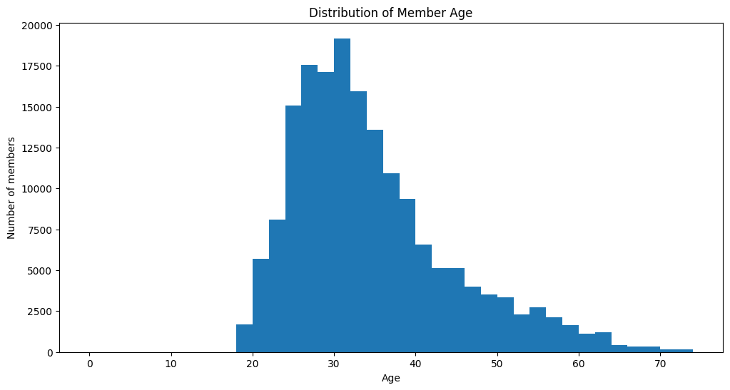

```python
bin_size = 2
bins = np.arange(0, df['member_age'].max() + bin_size, bin_size)
plt.figure(figsize=(12, 6))
plt.hist(data=df, x='member_age', bins=bins)
plt.xlabel('Age')
plt.ylabel('Number of members')
plt.title('Distribution of Member Age')
plt.show()
```

After cleaning, it is clear to see that the majority of cycling members are around 20-40 years old.

Next, I will investigate users' gender

### member_gender

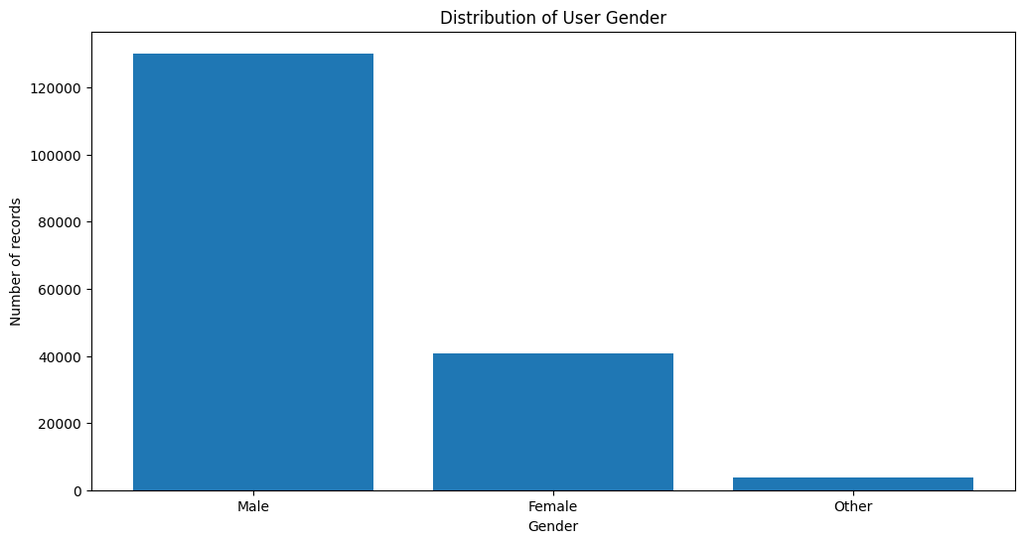

```python
# plotting gender of users
plt.figure(figsize=(12, 6))
plt.bar(x = df["member_gender"].value_counts().keys(), height = df["member_gender"].value_counts())
plt.title('Distribution of User Gender')
plt.xlabel('Gender')
plt.ylabel('Number of records')
plt.show()
```

Here, we can see that most of the users are man, and then female and other

Next, I will investigate the type os users

### user_type

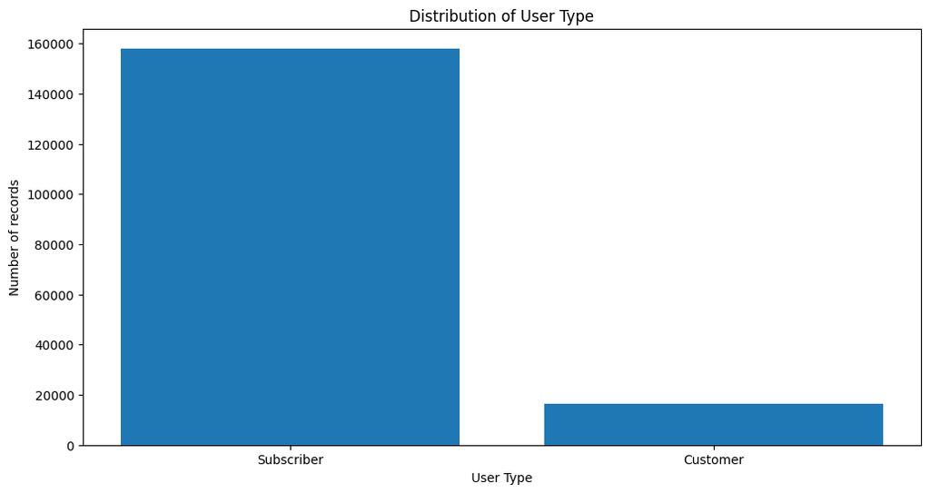

```python
# plotting types of users
plt.figure(figsize=(12, 6))
plt.bar(x = df["user_type"].value_counts().keys(), height = df["user_type"].value_counts())
plt.title('Distribution of User Type')
plt.xlabel('User Type')
plt.ylabel('Number of records')
plt.show()
```

Next, I will investigate the start_time feature by visualizing it by day of week and by hour

### start_time - start_time_dow - start_time_hour

```python
# Convert datetime to day of week and hour
df["start_time_dow"] = df["start_time"].dt.dayofweek
df["start_time_dow"] = df["start_time_dow"].map({0: "Monday", 1: "Tuesday", 2: "Wednesday", 3: "Thursday", 4: "Friday", 5: "Saturday", 6: "Sunday"})
df["start_time_hour"] = df["start_time"].dt.hour
```

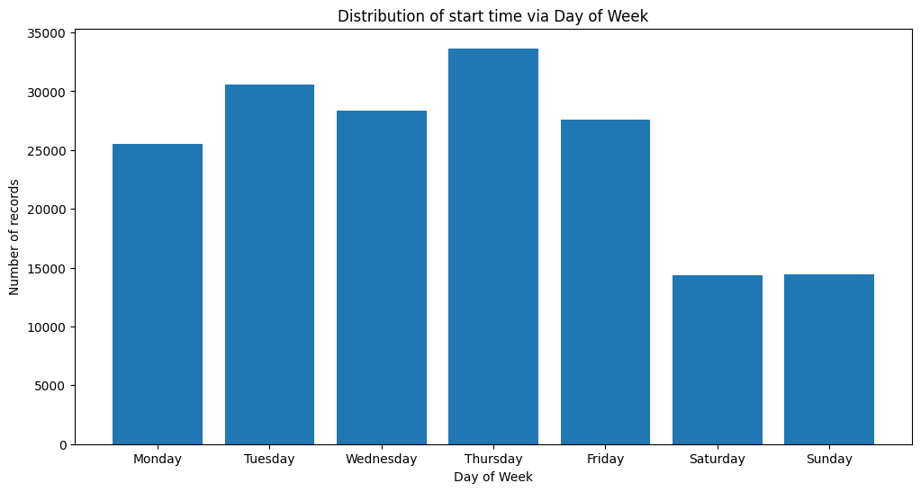

```python
dows = ["Monday", "Tuesday", "Wednesday", "Thursday", "Friday", "Saturday", "Sunday"]
dows_count = [df["start_time_dow"].value_counts()[dow] for dow in dows]
plt.figure(figsize=(12, 6))
plt.bar(x = dows, height = dows_count)
plt.title('Distribution of start time via Day of Week')
plt.xlabel('Day of Week')
plt.ylabel('Number of records')
plt.show()
```

It can be seen that users cycling the most in weekdays, especially on Tuesday and Thursday

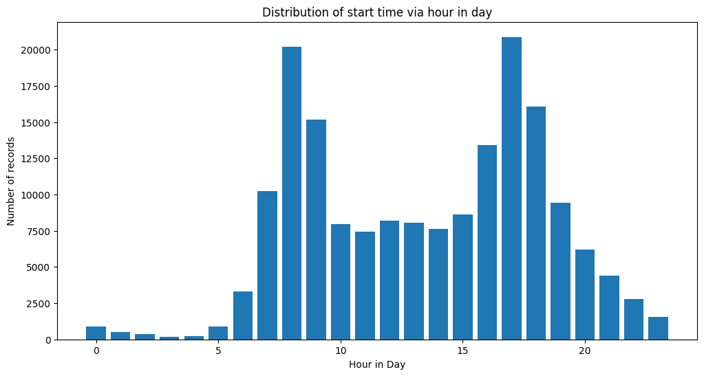

```python
plt.figure(figsize=(12, 6))
plt.bar(x = df["start_time_hour"].value_counts().keys(), height = df["start_time_hour"].value_counts())
plt.title('Distribution of start time via hour in day')
plt.xlabel('Hour in Day')
plt.ylabel('Number of records')
plt.show()
```

The majority of cycling records are around 8a.m and 5p.m

Now, I will investigate the distance of trips in the dataset. The distance will be calculated via start_station and end_station coordinates. To do this, I will use the geopy library

### start&end station location - distance_km

```python
!pip install geopy
```

```python
from geopy import distance
def calculate_distance_km(row):
    start_point = (row["start_station_latitude"], row["start_station_longitude"])
    end_point = (row["end_station_latitude"], row["end_station_longitude"])
    return distance.distance(start_point, end_point).km

df["distance_km"] = df.apply(calculate_distance_km, axis=1)
df.head()
```

|  | duration_sec | start_time | end_time | start_station_id | start_station_name | start_station_latitude | start_station_longitude | end_station_id | end_station_name | end_station_latitude | end_station_longitude | bike_id | user_type | member_birth_year | member_gender | bike_share_for_all_trip | member_age | start_time_dow | start_time_hour | distance_km |
| --- | --- | --- | --- | --- | --- | --- | --- | --- | --- | --- | --- | --- | --- | --- | --- | --- | --- | --- | --- | --- |
| 0 | 52185 | 2019-02-28 17:32:10.145 | 2019-03-01 08:01:55.975 | 21.0 | Montgomery St BART Station (Market St at 2nd St) | 37.789625 | -122.400811 | 13.0 | Commercial St at Montgomery St | 37.794231 | -122.402923 | 4902 | Customer | 1984.0 | Male | No | 35.0 | Thursday | 17 | 0.543983 |
| 2 | 61854 | 2019-02-28 12:13:13.218 | 2019-03-01 05:24:08.146 | 86.0 | Market St at Dolores St | 37.769305 | -122.426826 | 3.0 | Powell St BART Station (Market St at 4th St) | 37.786375 | -122.404904 | 5905 | Customer | 1972.0 | Male | No | 47.0 | Thursday | 12 | 2.705390 |
| 3 | 36490 | 2019-02-28 17:54:26.010 | 2019-03-01 04:02:36.842 | 375.0 | Grove St at Masonic Ave | 37.774836 | -122.446546 | 70.0 | Central Ave at Fell St | 37.773311 | -122.444293 | 6638 | Subscriber | 1989.0 | Other | No | 30.0 | Thursday | 17 | 0.260896 |
| 4 | 1585 | 2019-02-28 23:54:18.549 | 2019-03-01 00:20:44.074 | 7.0 | Frank H Ogawa Plaza | 37.804562 | -122.271738 | 222.0 | 10th Ave at E 15th St | 37.792714 | -122.248780 | 4898 | Subscriber | 1974.0 | Male | Yes | 45.0 | Thursday | 23 | 2.412017 |
| 5 | 1793 | 2019-02-28 23:49:58.632 | 2019-03-01 00:19:51.760 | 93.0 | 4th St at Mission Bay Blvd S | 37.770407 | -122.391198 | 323.0 | Broadway at Kearny | 37.798014 | -122.405950 | 5200 | Subscriber | 1959.0 | Male | No | 60.0 | Thursday | 23 | 3.328256 |

```python
# Descriptive statistic of distance_km
df["distance_km"].describe()
```

```
count    174582.000000
mean          1.690668
std           1.096400
min           0.000000
25%           0.909777
50%           1.428770
75%           2.225866
max          69.465977
Name: distance_km, dtype: float64
```

```python
distance_iqr = df["distance_km"].quantile(0.75) - df["distance_km"].quantile(0.25)
distance_upper_whisker_bound = min(df["distance_km"].max(), df["distance_km"].quantile(0.75) + 1.5 * distance_iqr)
distance_lower_whisker_bound = max(df["distance_km"].min(), df["distance_km"].quantile(0.25) - 1.5 * distance_iqr)
print("Distance")
print("IQR: ", distance_iqr)
print("Upper whisker bound: ", distance_upper_whisker_bound)
print("Lower whisker bound: ", distance_lower_whisker_bound)
```

```
Distance
IQR:  1.3160886824172504
Upper whisker bound:  4.199998956911212
Lower whisker bound:  0.0
```

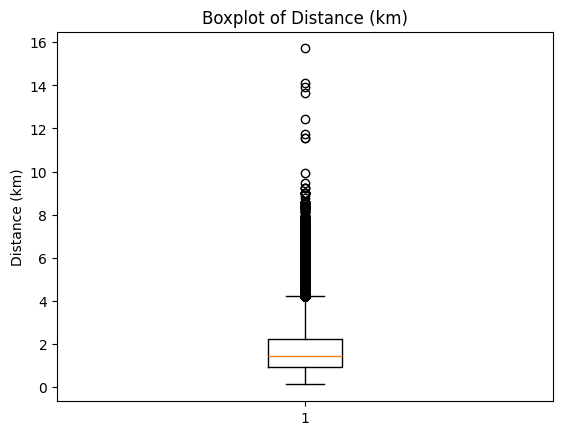

```python
# Remove the outliers in distance_km, which are the records with distance_km less than 0.1km and greater than 20km
df = df[(df["distance_km"] >= 0.1) & (df["distance_km"] <= 20)]
plt.boxplot(df["distance_km"])
plt.ylabel("Distance (km)")
plt.title("Boxplot of Distance (km)")
plt.show()
```

### Discuss the distribution(s) of your variable(s) of interest. Were there any unusual points? Did you need to perform any transformations?

> The trip duration distribution looks close to normal distribution. Its peak is concentrated at around 500-700 seconds and then the distribution starts to dip and there is no other peak value.

### Of the features you investigated, were there any unusual distributions? Did you perform any operations on the data to tidy, adjust, or change the form of the data? If so, why did you do this?

> There are some unusual in the member_birth_year and location of start and end station of the trip
> - member_birth_year: This feature is converted to member_age by subtracting with the year of this dataset recorded - 2019. After that, there're some outliers like the age is above 100 years old, so I remove those records
> - station location: These features are converted to distance of the trip in kilometers. Hence, I remove trips with very short travelling distance, which are those below 0.1 and trips with very long distance, those greater than 20km.

## Bivariate Exploration

First, I will plot the correlation of duration_sec with other numerical features above with a heatmap

### duration_sec X (member_age, distance_km)

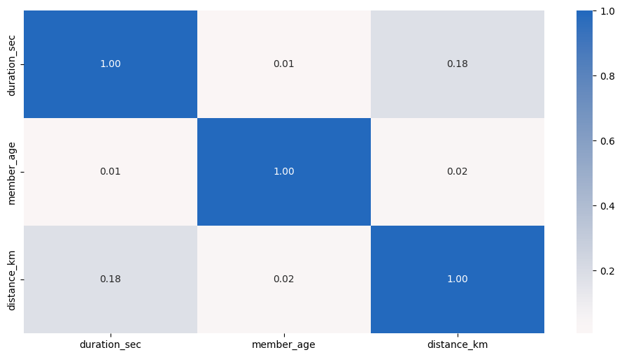

```python
plt.figure(figsize=(12, 6))
sns.heatmap(df[["duration_sec", "member_age", "distance_km"]].corr(), annot=True, fmt=".2f", cmap='vlag_r', center=0)
```

The correlation coefficients plot illustrates that there can be a positive correlation between duration_sec and distance_km. This can be naive explained that with records with longer distance will likely to have longer duration.

Other than that, there is no clear correlation with duration_sec

I will plot some scatterplot for more details

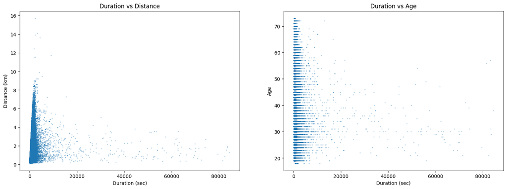

```python
plt.figure(figsize=(18, 6))
plt.subplot(1, 2, 1)
plt.scatter(data=df, x="duration_sec", y="distance_km", s=1.5, alpha=0.25)
plt.xlabel("Duration (sec)")
plt.ylabel("Distance (km)")
plt.title("Duration vs Distance")

plt.subplot(1, 2, 2)
plt.scatter(data=df, x="duration_sec", y="member_age", s=1.5, alpha=0.25)
plt.xlabel("Duration (sec)")
plt.ylabel("Age")
plt.title("Duration vs Age")

plt.show()
```

- The scatter plot between duration and distance: There is a dense area in the left bottom of the plot, with the value of duration < 20k sec and distance < 10km.
- The scatter plot between duration and age: There is dense area with the value of duration less than 20k of all age.

Now, I will go for other categorical features in the dataset

### duration_sec X user_type

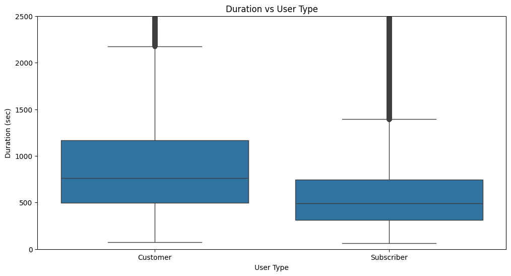

```python
# Duration vs User Type
plt.figure(figsize=(12, 6))
sns.boxplot(df, x="user_type", y="duration_sec")
plt.xlabel("User Type")
plt.ylim((0, 2500)) # Limit the y-axis to 2500 seconds to have a better view
plt.ylabel("Duration (sec)")
plt.title("Duration vs User Type")
plt.show()
```

It is clear that the average duration of Customer are higher than Subcriber, even though the number of Subcriber is much higher than that of Customer

### duration_sec X member_gender

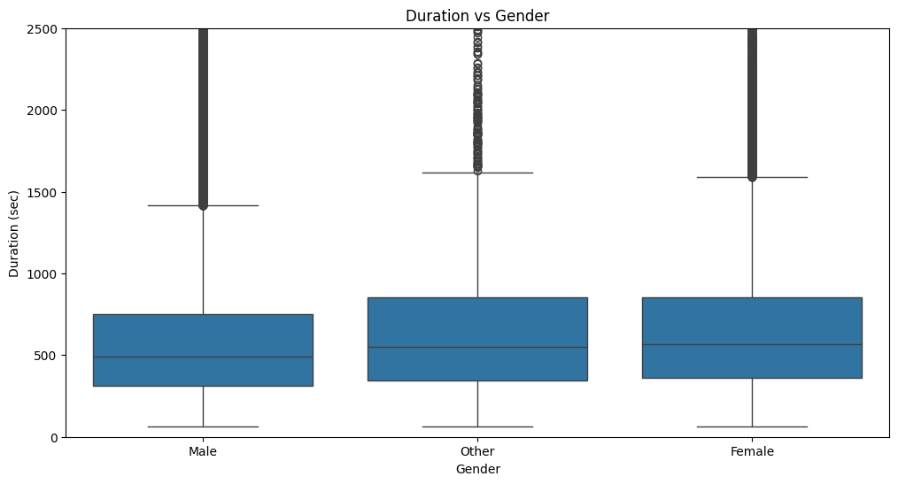

```python
plt.figure(figsize=(12, 6))
sns.boxplot(df, x="member_gender", y="duration_sec")
plt.ylim((0, 2500)) # Limit the y-axis to 2500 seconds to have a better view
plt.xlabel("Gender")
plt.ylabel("Duration (sec)")
plt.title("Duration vs Gender")
plt.show()
```

It can be seen that there's a higher percentage of female and other rides longer trips than males although number of male riders are the highest in the dataset

### duration_sec X start_time_dow

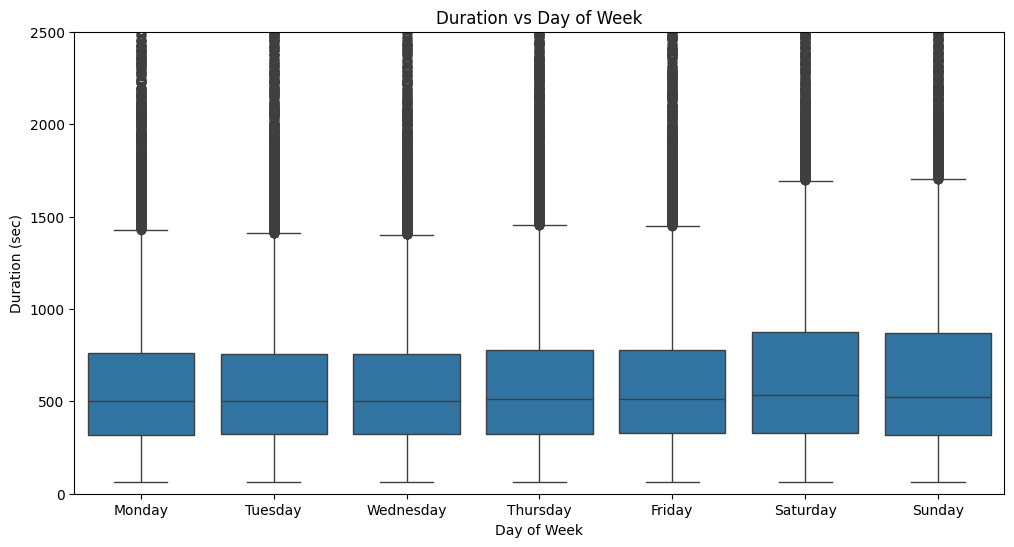

```python
plt.figure(figsize=(12, 6))
sns.boxplot(df, x="start_time_dow", y="duration_sec", order=dows)
plt.ylim((0, 2500)) # Limit the y-axis to 2500 seconds to have a better view
plt.xlabel("Day of Week")
plt.ylabel("Duration (sec)")
plt.title("Duration vs Day of Week")
plt.show()
```

It can be seen that in weekdays, the average duration of trip are a bit lower than that in the weekend

### duration_sec X start_time_hour

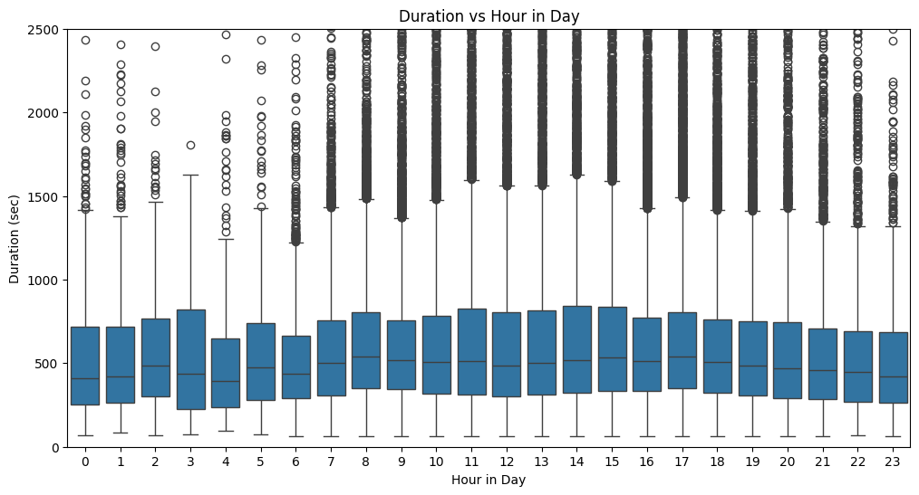

```python
plt.figure(figsize=(12, 6))
sns.boxplot(df, x="start_time_hour", y="duration_sec")
plt.ylim((0, 2500)) # Limit the y-axis to 2500 seconds to have a better view
plt.xlabel("Hour in Day")
plt.ylabel("Duration (sec)")
plt.title("Duration vs Hour in Day")
plt.show()
```

It is clear that there is no noticable differences between the duration in different hours in a day

### member_age X (user_type, member_gender)

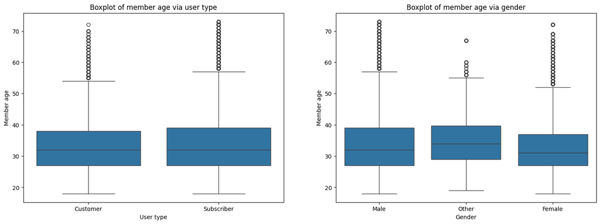

```python
plt.figure(figsize=(18, 6))

plt.subplot(1, 2, 1)
sns.boxplot(df, x="user_type", y="member_age")
plt.xlabel("User type")
plt.ylabel("Member age")
plt.title("Boxplot of member age via user type")

plt.subplot(1, 2, 2)
sns.boxplot(df, x="member_gender", y="member_age")
plt.xlabel("Gender")
plt.ylabel("Member age")
plt.title("Boxplot of member age via gender")
plt.show()
```

### Talk about some of the relationships you observed in this part of the investigation. How did the feature(s) of interest vary with other features in the dataset?

> - The trip duration on Saturday and Sunday is longer than compared to bike rides on other weekdays
> - Female riders cycle longer than male riders, on average
> - Riders who are not members (or suscribers) ride longer than cyclists who are subscribers

## Multivariate Exploration

### duration_sec X member_age via start_time_dow

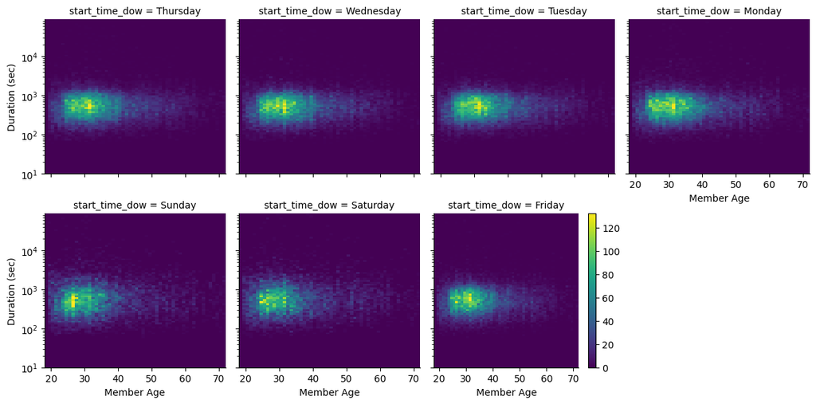

```python
def hist2d_duration_age(x, y, **kwargs):
    cmap = kwargs.pop('cmap', None)
    member_age_bins = np.arange(df["member_age"].min(), df["member_age"].max(), 1)
    duration_sec_bins = 10 ** np.arange(np.floor(np.log10(df["duration_sec"]).min()), np.log10(df["duration_sec"]).max() + 0.05, 0.05)
    plt.hist2d(x, y, bins=[member_age_bins, duration_sec_bins], cmap = cmap)
    plt.yscale('log')

g = sns.FacetGrid(data=df, col='start_time_dow', col_wrap=4)
g.map(hist2d_duration_age, 'member_age', 'duration_sec', cmap=None)
plt.colorbar()
g.set_xlabels('Member Age')
g.set_ylabels('Duration (sec)')
```

It is clear that there are more younger riders (with age < 45) in all days of week. Moreover, the cycling duration at weekend is longer than in the weekdays

### duration_sec X member_age via start_time_hour

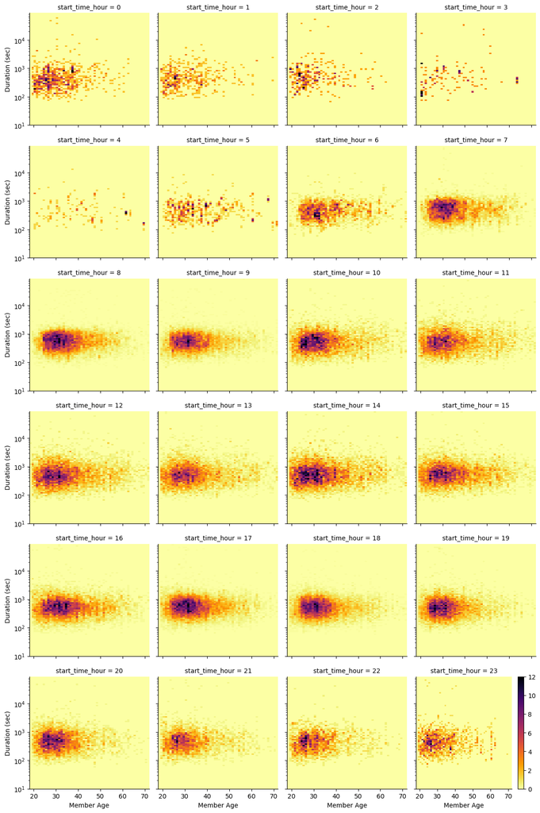

```python
g = sns.FacetGrid(data=df, col='start_time_hour', col_wrap=4)
g.map(hist2d_duration_age, 'member_age', 'duration_sec', cmap="inferno_r")
plt.colorbar()
g.set_xlabels('Member Age')
g.set_ylabels('Duration (sec)')
```

### duration_sec X member_age via user_type

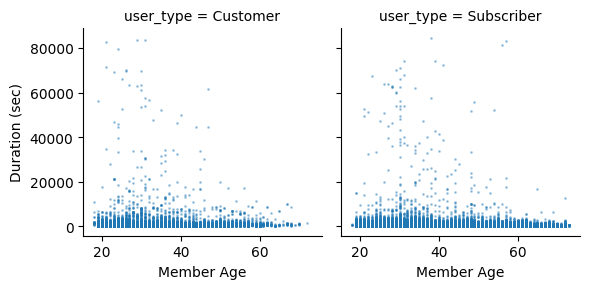

```python
g = sns.FacetGrid(data = df, col = 'user_type')
g.map(plt.scatter, 'member_age', 'duration_sec', alpha=0.35, s=1)
g.set_xlabels('Member Age')
g.set_ylabels('Duration (sec)')
# plt.yscale('log')
plt.show()
```

Older "Subcriber" riders have longer trip duration than Older "Customer" riders (whose age > 45)

### Talk about some of the relationships you observed in this part of the investigation. Were there features that strengthened each other in terms of looking at your feature(s) of interest?

> - In all days of week, younger riders (age < 45) cycling more than older riders (age >= 45)
> - The trip duration in the weekend is longer than that in the weekdays
> - There are most riders at 8a.m or 5p.m

### Were there any interesting or surprising interactions between features?

> Older age "Customer" riders have lower trip duration than that of "Subcriber", eventhough "Customer" riders have longer average trip duration than "Subcriber"